# Lecture 12: Discussion of Hinnov and Goldhammer (1991)

1. Geological setting
2. Cycles in the Latemar Limestone (**space**)
3. Potential origin of the Latemar cycles (**time**)
4. Testing the hypothesis: the data
5. Testing the hypothesis: the analysis

```python
import random
def pick_group(class_list):
    if len(class_list)>0:
        picked=random.sample(class_list,2)
        [class_list.remove(p) for p in picked]
        print(' and '.join(picked))
    else:
        picked=[]
    return class_list,picked
```

# Geological setting

- why would a platformal setting be especially senstive to sea level changes?

[figure not shown]

```python
class_list = ['Kai','Stacey','Grace','Liam','Matteo','Matthew','Noa','Izzy','Felix','Rhys','Andrea','Kristyn']
class_list,picked=pick_group(class_list)
```

```
Andrea and Kai
```

# Geological setting

[figure not shown]

```python
class_list = ['Kai','Stacey','Grace','Liam','Matteo','Matthew','Noa','Izzy','Felix','Rhys','Andrea','Kristyn']
class_list,picked=pick_group(class_list)
```

```
Grace and Rhys
```

# An ideal cycles in the Latemar Limestone

- what do the authors think is happening to sea level during deposition?
- "*The absence of features indicating peritidal deposition between the subtidal member and vadose cap is conspicuous throughout the formation.*"

[figure not shown]

```python
class_list = ['Stacey','Liam','Matteo','Matthew','Noa','Izzy','Felix','Kristyn']
class_list,picked=pick_group(class_list)
```

```
Izzy and Noa
```

# Nested cycles in the Latemar Limestone

- where is the *ideal Latemar cycle* on this plot?
- what is happening to **cycle thickness** up section?
- what do the authors think is happening to sea level?

[figure not shown]

# What is the propesed driver of cyclicity?

- what is driving an *ideal cycle*?
- what is driving the *bundling of cycles* into groups of five?

[figure not shown]

```python
class_list = ['Stacey','Liam','Matteo','Matthew','Felix','Kristyn']
class_list,picked=pick_group(class_list)
```

```
Matthew and Matteo
```

[figure not shown]

# But then why are the bundles asymmetric (according to the authors)?

[figure not shown]

```python
class_list = ['Kai','Stacey','Grace','Liam','Matteo','Matthew','Noa','Izzy','Felix','Rhys','Andrea','Kristyn']
class_list,picked=pick_group(class_list)
```

[output not shown]

```python
class_list = ['Kai','Stacey','Grace','Liam','Matteo','Matthew','Noa','Izzy','Felix','Rhys','Andrea','Kristyn']
class_list,picked=pick_group(class_list)
```

[output not shown]

# How then is time distributed in the Latemar succession?

- How long does one cycle last? How about 5 cycles?

[figure not shown]

# Testing the hypothesis: how are they going to do it?

[figure not shown]

```python
class_list = ['Stacey','Liam','Felix','Kristyn']
class_list,picked=pick_group(class_list)
```

```
Felix and Stacey
```

# Testing the hypothesis: the analysis

#### Authors need to accomplish two things:

[figure not shown]

# Testing the hypothesis: the analysis

[figure not shown]

# Overtones

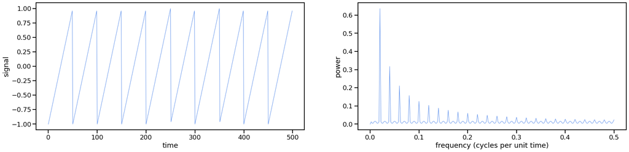

```python
#make some white noise
N=500
t = np.arange(0.0, 500, 1)
meas=scipy.signal.sawtooth((2*np.pi*t)/50)
mf=fft(meas - np.mean(meas))
tf,power,results=fft_axes(mf,N,N,1)
#plot
fig1=plt.figure(1,figsize=(27,6))
ax1=fig1.add_subplot(121)
ax1.set_xlabel('time')
ax1.set_ylabel('signal')
ax1.plot(meas,'-',lw=1,color='#6495ED')
ax1=fig1.add_subplot(122)
ax1.plot(tf,power,'-',lw=1,color='#6495ED')
ax1.set_xlabel('frequency (cycles per unit time)')
_=ax1.set_ylabel('power')
```

# Noise: red or white?

```python
from scipy.fftpack import fft
import matplotlib.pyplot as plt
import numpy as np
from scipy import signal
import pandas as pd
import seaborn as sns
sns.set_context('talk')
%matplotlib inline

def fft_axes(yf,T,N,dt):

    if N % 2==0:
        xf=np.hstack((np.arange(0,1/(2*dt),1/T),(N//2)/T))
        power=2.0/N *np.abs(yf[0:len(xf)])
    else:
        xf=np.arange(0,1/(2*dt),1/T)
        power=2.0/N *np.abs(yf[0:len(xf)])

    results=pd.DataFrame(zip(xf,power),columns=['freq','power'])
    results=results.sort_values(by=['power'],ascending=False)

    return xf,power,results
```

```python
#make some white noise
N=500
t = np.arange(0.0, 500, 1)
meas=np.random.uniform(size=500)
#periodic signal
amp=0.0 #amp=0.065 #amp=0.13
ang_freq=0.02
meas=meas + amp*np.sin(ang_freq* 2*np.pi*t)
#fft
mf=fft(meas - np.mean(meas))
tf,power,results=fft_axes(mf,N,N,1)
#plot
fig1=plt.figure(1,figsize=(27,6))
ax1=fig1.add_subplot(121)
ax1.set_xlabel('time')
ax1.set_ylabel('signal')
ax1.plot(meas,'-',lw=1,color='#6495ED')
ax1=fig1.add_subplot(122)
ax1.plot(tf,power,'-',lw=1,color='#6495ED')
# ax1.annotate('our signal',(ang_freq,power[tf==ang_freq][0]),xytext=(50, 0), textcoords='offset points',fontsize=16,arrowprops=dict(arrowstyle="->"))
ax1.set_xlabel('frequency (cycles per unit time)')
_=ax1.set_ylabel('power')
```

[output not shown]

```python
#make some red noise
t = np.arange(0.0, 500, 1)
meas=np.random.randint(-1,2,500)
meas=np.cumsum(meas)
#periodic signal
amp=2 #amp=2
ang_freq=0.02
meas=meas + amp*np.sin(ang_freq * 2*np.pi*t)
#fft
mf=fft(meas - np.mean(meas))
tf,power,results=fft_axes(mf,N,N,1)
#plot
fig1=plt.figure(1,figsize=(27,6))
ax1=fig1.add_subplot(121)
ax1.set_xlabel('time')
ax1.plot(meas,'-',lw=1,color='#6495ED')
ax1=fig1.add_subplot(122)
# ax1.plot(tf,power,'-',lw=1,color='#6495ED')
ax1.plot(np.log10(tf[1:]),np.log10(power[1:]),'-',lw=1,color='#6495ED')
# ax1.annotate('our signal',(np.log10(ang_freq),np.log10(power[tf==ang_freq][0])),xytext=(50, 0), textcoords='offset points',fontsize=16,arrowprops=dict(arrowstyle="->"))
ax1.set_xlabel('frequency (cycles per unit time)')
_=ax1.set_ylabel('power')
```

[output not shown]

```python
#make some white noise
N=100
t = np.linspace(0.0, N, 100000)
meas=2*np.sin((2*np.pi*t)/50)+np.cos(2*np.pi*t/10)

#plot
fig1=plt.figure(1,figsize=(27,6))
plt.plot(t,meas+t/5)
```

[output not shown]